# Risk Factor Analysis

## Outcome Variable

**Outcome Variable:** stunted

## Predictor Variables

**Intervention Variable:** birthwt

**Adjustment Set:**

unadjusted

## Stratifying Variables

The analysis was stratified on these variable(s):

- agecat
- studyid
- country

## Data Summary

| agecat | studyid | country | birthwt | stunted | n_cell | n |
| --- | --- | --- | --- | --- | --- | --- |
| Birth | ki0047075b-MAL-ED | BANGLADESH | Normal or high birthweight | 0 | 186 | 257 |
| Birth | ki0047075b-MAL-ED | BANGLADESH | Normal or high birthweight | 1 | 16 | 257 |
| Birth | ki0047075b-MAL-ED | BANGLADESH | Low birth weight | 0 | 24 | 257 |
| Birth | ki0047075b-MAL-ED | BANGLADESH | Low birth weight | 1 | 31 | 257 |
| Birth | ki0047075b-MAL-ED | BRAZIL | Normal or high birthweight | 0 | 168 | 191 |
| Birth | ki0047075b-MAL-ED | BRAZIL | Normal or high birthweight | 1 | 15 | 191 |
| Birth | ki0047075b-MAL-ED | BRAZIL | Low birth weight | 0 | 2 | 191 |
| Birth | ki0047075b-MAL-ED | BRAZIL | Low birth weight | 1 | 6 | 191 |
| Birth | ki0047075b-MAL-ED | INDIA | Normal or high birthweight | 0 | 154 | 206 |
| Birth | ki0047075b-MAL-ED | INDIA | Normal or high birthweight | 1 | 18 | 206 |
| Birth | ki0047075b-MAL-ED | INDIA | Low birth weight | 0 | 19 | 206 |
| Birth | ki0047075b-MAL-ED | INDIA | Low birth weight | 1 | 15 | 206 |
| Birth | ki0047075b-MAL-ED | NEPAL | Normal or high birthweight | 0 | 148 | 173 |
| Birth | ki0047075b-MAL-ED | NEPAL | Normal or high birthweight | 1 | 7 | 173 |
| Birth | ki0047075b-MAL-ED | NEPAL | Low birth weight | 0 | 7 | 173 |
| Birth | ki0047075b-MAL-ED | NEPAL | Low birth weight | 1 | 11 | 173 |
| Birth | ki0047075b-MAL-ED | PERU | Normal or high birthweight | 0 | 251 | 287 |
| Birth | ki0047075b-MAL-ED | PERU | Normal or high birthweight | 1 | 18 | 287 |
| Birth | ki0047075b-MAL-ED | PERU | Low birth weight | 0 | 2 | 287 |
| Birth | ki0047075b-MAL-ED | PERU | Low birth weight | 1 | 16 | 287 |
| Birth | ki0047075b-MAL-ED | SOUTH AFRICA | Normal or high birthweight | 0 | 227 | 262 |
| Birth | ki0047075b-MAL-ED | SOUTH AFRICA | Normal or high birthweight | 1 | 17 | 262 |
| Birth | ki0047075b-MAL-ED | SOUTH AFRICA | Low birth weight | 0 | 7 | 262 |
| Birth | ki0047075b-MAL-ED | SOUTH AFRICA | Low birth weight | 1 | 11 | 262 |
| Birth | ki0047075b-MAL-ED | TANZANIA, UNITED REPUBLIC OF | Normal or high birthweight | 0 | 104 | 123 |
| Birth | ki0047075b-MAL-ED | TANZANIA, UNITED REPUBLIC OF | Normal or high birthweight | 1 | 12 | 123 |
| Birth | ki0047075b-MAL-ED | TANZANIA, UNITED REPUBLIC OF | Low birth weight | 0 | 1 | 123 |
| Birth | ki0047075b-MAL-ED | TANZANIA, UNITED REPUBLIC OF | Low birth weight | 1 | 6 | 123 |
| Birth | ki1000108-CMC-V-BCS-2002 | INDIA | Normal or high birthweight | 0 | 70 | 90 |
| Birth | ki1000108-CMC-V-BCS-2002 | INDIA | Normal or high birthweight | 1 | 10 | 90 |

[output cut: 286 more lines]

The following strata were considered:

- agecat: 24 months, studyid: ki0047075b-MAL-ED, country: BANGLADESH
- agecat: 24 months, studyid: ki0047075b-MAL-ED, country: BRAZIL
- agecat: 24 months, studyid: ki0047075b-MAL-ED, country: INDIA
- agecat: 24 months, studyid: ki0047075b-MAL-ED, country: NEPAL
- agecat: 24 months, studyid: ki0047075b-MAL-ED, country: PERU
- agecat: 24 months, studyid: ki0047075b-MAL-ED, country: SOUTH AFRICA
- agecat: 24 months, studyid: ki0047075b-MAL-ED, country: TANZANIA, UNITED REPUBLIC OF
- agecat: 24 months, studyid: ki1000108-CMC-V-BCS-2002, country: INDIA
- agecat: 24 months, studyid: ki1000108-IRC, country: INDIA
- agecat: 24 months, studyid: ki1017093-NIH-Birth, country: BANGLADESH
- agecat: 24 months, studyid: ki1017093b-PROVIDE, country: BANGLADESH
- agecat: 24 months, studyid: ki1017093c-NIH-Crypto, country: BANGLADESH
- agecat: 24 months, studyid: ki1066203-TanzaniaChild2, country: TANZANIA, UNITED REPUBLIC OF
- agecat: 24 months, studyid: ki1101329-Keneba, country: GAMBIA
- agecat: 24 months, studyid: ki1114097-CMIN, country: BANGLADESH
- agecat: 24 months, studyid: ki1114097-CMIN, country: PERU
- agecat: 24 months, studyid: ki1114097-CONTENT, country: PERU
- agecat: 24 months, studyid: ki1119695-PROBIT, country: BELARUS
- agecat: 24 months, studyid: ki1126311-ZVITAMBO, country: ZIMBABWE
- agecat: 24 months, studyid: ki1135781-COHORTS, country: GUATEMALA
- agecat: 24 months, studyid: ki1135781-COHORTS, country: INDIA
- agecat: 24 months, studyid: ki1135781-COHORTS, country: PHILIPPINES
- agecat: 24 months, studyid: kiGH5241-JiVitA-3, country: BANGLADESH
- agecat: 24 months, studyid: kiGH5241-JiVitA-4, country: BANGLADESH
- agecat: 6 months, studyid: ki0047075b-MAL-ED, country: BANGLADESH
- agecat: 6 months, studyid: ki0047075b-MAL-ED, country: BRAZIL
- agecat: 6 months, studyid: ki0047075b-MAL-ED, country: INDIA
- agecat: 6 months, studyid: ki0047075b-MAL-ED, country: NEPAL
- agecat: 6 months, studyid: ki0047075b-MAL-ED, country: PERU
- agecat: 6 months, studyid: ki0047075b-MAL-ED, country: SOUTH AFRICA
- agecat: 6 months, studyid: ki0047075b-MAL-ED, country: TANZANIA, UNITED REPUBLIC OF
- agecat: 6 months, studyid: ki1000108-CMC-V-BCS-2002, country: INDIA
- agecat: 6 months, studyid: ki1000108-IRC, country: INDIA
- agecat: 6 months, studyid: ki1000109-EE, country: PAKISTAN
- agecat: 6 months, studyid: ki1000109-ResPak, country: PAKISTAN
- agecat: 6 months, studyid: ki1000304b-SAS-CompFeed, country: INDIA
- agecat: 6 months, studyid: ki1017093-NIH-Birth, country: BANGLADESH
- agecat: 6 months, studyid: ki1017093b-PROVIDE, country: BANGLADESH
- agecat: 6 months, studyid: ki1017093c-NIH-Crypto, country: BANGLADESH
- agecat: 6 months, studyid: ki1066203-TanzaniaChild2, country: TANZANIA, UNITED REPUBLIC OF
- agecat: 6 months, studyid: ki1101329-Keneba, country: GAMBIA
- agecat: 6 months, studyid: ki1114097-CMIN, country: BANGLADESH
- agecat: 6 months, studyid: ki1114097-CMIN, country: BRAZIL
- agecat: 6 months, studyid: ki1114097-CMIN, country: GUINEA-BISSAU
- agecat: 6 months, studyid: ki1114097-CMIN, country: PERU
- agecat: 6 months, studyid: ki1114097-CONTENT, country: PERU
- agecat: 6 months, studyid: ki1119695-PROBIT, country: BELARUS
- agecat: 6 months, studyid: ki1126311-ZVITAMBO, country: ZIMBABWE
- agecat: 6 months, studyid: ki1135781-COHORTS, country: GUATEMALA
- agecat: 6 months, studyid: ki1135781-COHORTS, country: INDIA
- agecat: 6 months, studyid: ki1135781-COHORTS, country: PHILIPPINES
- agecat: 6 months, studyid: kiGH5241-JiVitA-3, country: BANGLADESH
- agecat: 6 months, studyid: kiGH5241-JiVitA-4, country: BANGLADESH
- agecat: Birth, studyid: ki0047075b-MAL-ED, country: BANGLADESH
- agecat: Birth, studyid: ki0047075b-MAL-ED, country: BRAZIL
- agecat: Birth, studyid: ki0047075b-MAL-ED, country: INDIA
- agecat: Birth, studyid: ki0047075b-MAL-ED, country: NEPAL
- agecat: Birth, studyid: ki0047075b-MAL-ED, country: PERU
- agecat: Birth, studyid: ki0047075b-MAL-ED, country: SOUTH AFRICA
- agecat: Birth, studyid: ki0047075b-MAL-ED, country: TANZANIA, UNITED REPUBLIC OF
- agecat: Birth, studyid: ki1000108-CMC-V-BCS-2002, country: INDIA
- agecat: Birth, studyid: ki1000108-IRC, country: INDIA
- agecat: Birth, studyid: ki1000109-EE, country: PAKISTAN
- agecat: Birth, studyid: ki1000109-ResPak, country: PAKISTAN
- agecat: Birth, studyid: ki1000304b-SAS-CompFeed, country: INDIA
- agecat: Birth, studyid: ki1017093-NIH-Birth, country: BANGLADESH
- agecat: Birth, studyid: ki1017093c-NIH-Crypto, country: BANGLADESH
- agecat: Birth, studyid: ki1101329-Keneba, country: GAMBIA
- agecat: Birth, studyid: ki1114097-CMIN, country: BANGLADESH
- agecat: Birth, studyid: ki1114097-CMIN, country: BRAZIL
- agecat: Birth, studyid: ki1114097-CMIN, country: PERU
- agecat: Birth, studyid: ki1114097-CONTENT, country: PERU
- agecat: Birth, studyid: ki1119695-PROBIT, country: BELARUS
- agecat: Birth, studyid: ki1126311-ZVITAMBO, country: ZIMBABWE
- agecat: Birth, studyid: ki1135781-COHORTS, country: GUATEMALA
- agecat: Birth, studyid: ki1135781-COHORTS, country: INDIA
- agecat: Birth, studyid: ki1135781-COHORTS, country: PHILIPPINES
- agecat: Birth, studyid: kiGH5241-JiVitA-3, country: BANGLADESH
- agecat: Birth, studyid: kiGH5241-JiVitA-4, country: BANGLADESH

### Dropped Strata

Some strata were dropped due to rare outcomes:

- agecat: Birth, studyid: ki0047075b-MAL-ED, country: BRAZIL
- agecat: Birth, studyid: ki0047075b-MAL-ED, country: PERU
- agecat: Birth, studyid: ki0047075b-MAL-ED, country: TANZANIA, UNITED REPUBLIC OF
- agecat: Birth, studyid: ki1000108-CMC-V-BCS-2002, country: INDIA
- agecat: Birth, studyid: ki1000109-EE, country: PAKISTAN
- agecat: Birth, studyid: ki1000109-ResPak, country: PAKISTAN
- agecat: Birth, studyid: ki1017093-NIH-Birth, country: BANGLADESH
- agecat: Birth, studyid: ki1017093c-NIH-Crypto, country: BANGLADESH
- agecat: Birth, studyid: ki1114097-CMIN, country: BANGLADESH
- agecat: Birth, studyid: ki1114097-CMIN, country: BRAZIL
- agecat: Birth, studyid: ki1114097-CMIN, country: PERU
- agecat: Birth, studyid: ki1114097-CONTENT, country: PERU
- agecat: Birth, studyid: ki1119695-PROBIT, country: BELARUS
- agecat: 6 months, studyid: ki0047075b-MAL-ED, country: BRAZIL
- agecat: 6 months, studyid: ki0047075b-MAL-ED, country: TANZANIA, UNITED REPUBLIC OF
- agecat: 6 months, studyid: ki1000109-ResPak, country: PAKISTAN
- agecat: 6 months, studyid: ki1114097-CMIN, country: BANGLADESH
- agecat: 6 months, studyid: ki1114097-CMIN, country: BRAZIL
- agecat: 6 months, studyid: ki1114097-CMIN, country: GUINEA-BISSAU
- agecat: 6 months, studyid: ki1114097-CMIN, country: PERU
- agecat: 6 months, studyid: ki1114097-CONTENT, country: PERU
- agecat: 6 months, studyid: ki1119695-PROBIT, country: BELARUS
- agecat: 24 months, studyid: ki0047075b-MAL-ED, country: BRAZIL
- agecat: 24 months, studyid: ki0047075b-MAL-ED, country: PERU
- agecat: 24 months, studyid: ki0047075b-MAL-ED, country: SOUTH AFRICA
- agecat: 24 months, studyid: ki0047075b-MAL-ED, country: TANZANIA, UNITED REPUBLIC OF
- agecat: 24 months, studyid: ki1066203-TanzaniaChild2, country: TANZANIA, UNITED REPUBLIC OF
- agecat: 24 months, studyid: ki1114097-CMIN, country: BANGLADESH
- agecat: 24 months, studyid: ki1114097-CMIN, country: PERU
- agecat: 24 months, studyid: ki1114097-CONTENT, country: PERU
- agecat: 24 months, studyid: ki1119695-PROBIT, country: BELARUS
- agecat: 24 months, studyid: ki1135781-COHORTS, country: GUATEMALA

## Methods Detail

We’re interested in the causal parameters $E[Y_a]$ for all values of $a \in \mathcal{A}$. These parameters represent the mean outcome if, possibly contrary to fact, we intervened to set all units to have $A=a$. Under the randomization and positivity assumptions, these are identified by the statistical parameters $\psi_a=E_W[E_{Y|A,W}(Y|A=a,W)]$. In addition, we’re interested in the mean of $Y$, $E[Y]$ under no intervention (the observed mean). We will estimate these parameters by using SuperLearner to fit the relevant likelihood factors – $E_{Y|A,W}(Y|A=a,W)$ and $p(A=a|W)$, and then updating our likelihood fit using a joint TMLE.

For unadjusted analyses ($W=\{\}$), initial likelihoods were estimated using Lrnr_glm to estimate the simple $E(Y|A)$ and Lrnr_mean to estimate $p(A)$. For adjusted analyses, a small library containing Lrnr_glmnet, Lrnr_xgboost, and Lrnr_mean was used.

Having estimated these parameters, we will then use the delta method to estimate relative risks and attributable risks relative to a prespecified baseline level of $A$.

# Results Detail

## Results Plots

[figure not shown]

[figure not shown]

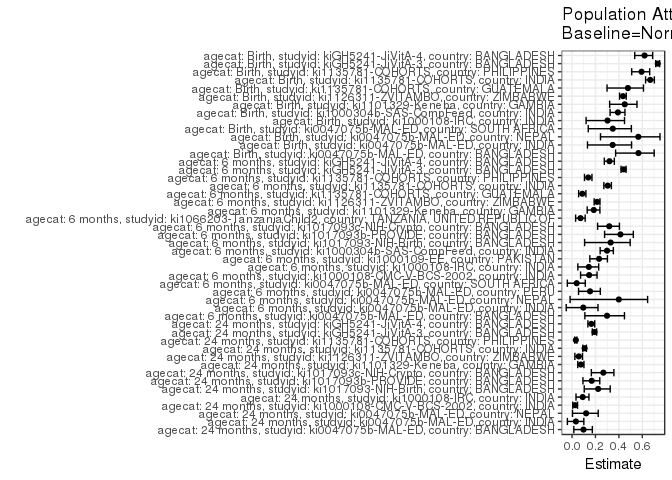

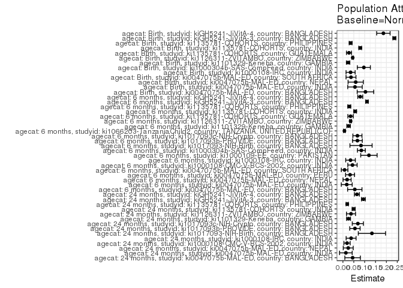

## Results Table

### Parameter: TSM

| agecat | studyid | country | intervention_level | baseline_level | estimate | ci_lower | ci_upper |
| --- | --- | --- | --- | --- | --- | --- | --- |
| Birth | ki0047075b-MAL-ED | BANGLADESH | Normal or high birthweight | NA | 0.0792079 | 0.0418929 | 0.1165230 |
| Birth | ki0047075b-MAL-ED | BANGLADESH | Low birth weight | NA | 0.5636364 | 0.4323145 | 0.6949582 |
| Birth | ki0047075b-MAL-ED | INDIA | Normal or high birthweight | NA | 0.1046512 | 0.0587938 | 0.1505085 |
| Birth | ki0047075b-MAL-ED | INDIA | Low birth weight | NA | 0.4411765 | 0.2738715 | 0.6084814 |
| Birth | ki0047075b-MAL-ED | NEPAL | Normal or high birthweight | NA | 0.0451613 | 0.0123752 | 0.0779474 |
| Birth | ki0047075b-MAL-ED | NEPAL | Low birth weight | NA | 0.6111111 | 0.3852489 | 0.8369733 |
| Birth | ki0047075b-MAL-ED | SOUTH AFRICA | Normal or high birthweight | NA | 0.0696721 | 0.0376662 | 0.1016781 |
| Birth | ki0047075b-MAL-ED | SOUTH AFRICA | Low birth weight | NA | 0.6111111 | 0.3854716 | 0.8367506 |
| Birth | ki1000108-IRC | INDIA | Normal or high birthweight | NA | 0.0812500 | 0.0512759 | 0.1112241 |
| Birth | ki1000108-IRC | INDIA | Low birth weight | NA | 0.2878788 | 0.1785030 | 0.3972546 |
| Birth | ki1000304b-SAS-CompFeed | INDIA | Normal or high birthweight | NA | 0.1496599 | 0.0881093 | 0.2112105 |
| Birth | ki1000304b-SAS-CompFeed | INDIA | Low birth weight | NA | 0.6000000 | 0.4488812 | 0.7511188 |
| Birth | ki1101329-Keneba | GAMBIA | Normal or high birthweight | NA | 0.0292648 | 0.0204362 | 0.0380934 |
| Birth | ki1101329-Keneba | GAMBIA | Low birth weight | NA | 0.2928571 | 0.2174510 | 0.3682633 |
| Birth | ki1126311-ZVITAMBO | ZIMBABWE | Normal or high birthweight | NA | 0.0585129 | 0.0543008 | 0.0627249 |
| Birth | ki1126311-ZVITAMBO | ZIMBABWE | Low birth weight | NA | 0.3861126 | 0.3642262 | 0.4079990 |
| Birth | ki1135781-COHORTS | GUATEMALA | Normal or high birthweight | NA | 0.0306834 | 0.0180520 | 0.0433148 |
| Birth | ki1135781-COHORTS | GUATEMALA | Low birth weight | NA | 0.3582090 | 0.2433267 | 0.4730912 |
| Birth | ki1135781-COHORTS | INDIA | Normal or high birthweight | NA | 0.0396735 | 0.0344022 | 0.0449448 |
| Birth | ki1135781-COHORTS | INDIA | Low birth weight | NA | 0.4255474 | 0.3993643 | 0.4517306 |
| Birth | ki1135781-COHORTS | PHILIPPINES | Normal or high birthweight | NA | 0.0243632 | 0.0185566 | 0.0301699 |
| Birth | ki1135781-COHORTS | PHILIPPINES | Low birth weight | NA | 0.3864407 | 0.3308657 | 0.4420156 |
| Birth | kiGH5241-JiVitA-3 | BANGLADESH | Normal or high birthweight | NA | 0.0866832 | 0.0805754 | 0.0927910 |
| Birth | kiGH5241-JiVitA-3 | BANGLADESH | Low birth weight | NA | 0.6441452 | 0.6328997 | 0.6553907 |
| Birth | kiGH5241-JiVitA-4 | BANGLADESH | Normal or high birthweight | NA | 0.1143376 | 0.0871152 | 0.1415599 |
| Birth | kiGH5241-JiVitA-4 | BANGLADESH | Low birth weight | NA | 0.6789668 | 0.6167319 | 0.7412017 |
| 6 months | ki0047075b-MAL-ED | BANGLADESH | Normal or high birthweight | NA | 0.1283422 | 0.0803013 | 0.1763831 |
| 6 months | ki0047075b-MAL-ED | BANGLADESH | Low birth weight | NA | 0.3958333 | 0.2571935 | 0.5344732 |
| 6 months | ki0047075b-MAL-ED | INDIA | Normal or high birthweight | NA | 0.1658031 | 0.1132195 | 0.2183867 |
| 6 months | ki0047075b-MAL-ED | INDIA | Low birth weight | NA | 0.2777778 | 0.1311449 | 0.4244106 |

[output cut: 64 more lines]

### Parameter: E(Y)

| agecat | studyid | country | intervention_level | baseline_level | estimate | ci_lower | ci_upper |
| --- | --- | --- | --- | --- | --- | --- | --- |
| Birth | ki0047075b-MAL-ED | BANGLADESH | NA | NA | 0.1828794 | 0.1355257 | 0.2302330 |
| Birth | ki0047075b-MAL-ED | INDIA | NA | NA | 0.1601942 | 0.1099849 | 0.2104035 |
| Birth | ki0047075b-MAL-ED | NEPAL | NA | NA | 0.1040462 | 0.0584174 | 0.1496751 |
| Birth | ki0047075b-MAL-ED | SOUTH AFRICA | NA | NA | 0.1068702 | 0.0693890 | 0.1443514 |
| Birth | ki1000108-IRC | INDIA | NA | NA | 0.1165803 | 0.0845240 | 0.1486366 |
| Birth | ki1000304b-SAS-CompFeed | INDIA | NA | NA | 0.2459893 | 0.1594019 | 0.3325767 |
| Birth | ki1101329-Keneba | GAMBIA | NA | NA | 0.0532122 | 0.0420018 | 0.0644226 |
| Birth | ki1126311-ZVITAMBO | ZIMBABWE | NA | NA | 0.1035430 | 0.0984652 | 0.1086208 |
| Birth | ki1135781-COHORTS | GUATEMALA | NA | NA | 0.0586735 | 0.0422124 | 0.0751345 |
| Birth | ki1135781-COHORTS | INDIA | NA | NA | 0.1193130 | 0.1115144 | 0.1271117 |
| Birth | ki1135781-COHORTS | PHILIPPINES | NA | NA | 0.0599201 | 0.0514314 | 0.0684088 |
| Birth | kiGH5241-JiVitA-3 | BANGLADESH | NA | NA | 0.3231185 | 0.3154668 | 0.3307702 |
| Birth | kiGH5241-JiVitA-4 | BANGLADESH | NA | NA | 0.3004866 | 0.2649179 | 0.3360553 |
| 6 months | ki0047075b-MAL-ED | BANGLADESH | NA | NA | 0.1829787 | 0.1334386 | 0.2325189 |
| 6 months | ki0047075b-MAL-ED | INDIA | NA | NA | 0.1834061 | 0.1331729 | 0.2336393 |
| 6 months | ki0047075b-MAL-ED | NEPAL | NA | NA | 0.0480349 | 0.0202781 | 0.0757918 |
| 6 months | ki0047075b-MAL-ED | PERU | NA | NA | 0.2148148 | 0.1657364 | 0.2638932 |
| 6 months | ki0047075b-MAL-ED | SOUTH AFRICA | NA | NA | 0.1968504 | 0.1478551 | 0.2458457 |
| 6 months | ki1000108-CMC-V-BCS-2002 | INDIA | NA | NA | 0.3008130 | 0.2539566 | 0.3476694 |
| 6 months | ki1000108-IRC | INDIA | NA | NA | 0.2444444 | 0.2025380 | 0.2863509 |
| 6 months | ki1000109-EE | PAKISTAN | NA | NA | 0.5188172 | 0.4679751 | 0.5696593 |
| 6 months | ki1000304b-SAS-CompFeed | INDIA | NA | NA | 0.2843137 | 0.2660295 | 0.3025980 |
| 6 months | ki1017093-NIH-Birth | BANGLADESH | NA | NA | 0.2528090 | 0.1887805 | 0.3168375 |
| 6 months | ki1017093b-PROVIDE | BANGLADESH | NA | NA | 0.1612350 | 0.1313580 | 0.1911120 |
| 6 months | ki1017093c-NIH-Crypto | BANGLADESH | NA | NA | 0.2097902 | 0.1799252 | 0.2396552 |
| 6 months | ki1066203-TanzaniaChild2 | TANZANIA, UNITED REPUBLIC OF | NA | NA | 0.0964694 | 0.0835627 | 0.1093762 |
| 6 months | ki1101329-Keneba | GAMBIA | NA | NA | 0.1414493 | 0.1249994 | 0.1578992 |
| 6 months | ki1126311-ZVITAMBO | ZIMBABWE | NA | NA | 0.1660012 | 0.1579791 | 0.1740234 |
| 6 months | ki1135781-COHORTS | GUATEMALA | NA | NA | 0.4007782 | 0.3661645 | 0.4353920 |
| 6 months | ki1135781-COHORTS | INDIA | NA | NA | 0.1852739 | 0.1756495 | 0.1948983 |
| 6 months | ki1135781-COHORTS | PHILIPPINES | NA | NA | 0.2108027 | 0.1953170 | 0.2262884 |
| 6 months | kiGH5241-JiVitA-3 | BANGLADESH | NA | NA | 0.2513890 | 0.2432761 | 0.2595019 |
| 6 months | kiGH5241-JiVitA-4 | BANGLADESH | NA | NA | 0.2495047 | 0.2333837 | 0.2656257 |
| 24 months | ki0047075b-MAL-ED | BANGLADESH | NA | NA | 0.4567308 | 0.3888728 | 0.5245887 |
| 24 months | ki0047075b-MAL-ED | INDIA | NA | NA | 0.4136364 | 0.3484106 | 0.4788621 |
| 24 months | ki0047075b-MAL-ED | NEPAL | NA | NA | 0.2036199 | 0.1504082 | 0.2568316 |
| 24 months | ki1000108-CMC-V-BCS-2002 | INDIA | NA | NA | 0.7150538 | 0.6691221 | 0.7609854 |
| 24 months | ki1000108-IRC | INDIA | NA | NA | 0.4152334 | 0.3673018 | 0.4631651 |
| 24 months | ki1017093-NIH-Birth | BANGLADESH | NA | NA | 0.5985401 | 0.5161555 | 0.6809248 |
| 24 months | ki1017093b-PROVIDE | BANGLADESH | NA | NA | 0.3292894 | 0.2909105 | 0.3676684 |
| 24 months | ki1017093c-NIH-Crypto | BANGLADESH | NA | NA | 0.2568093 | 0.2190047 | 0.2946140 |
| 24 months | ki1101329-Keneba | GAMBIA | NA | NA | 0.3426184 | 0.3180636 | 0.3671732 |
| 24 months | ki1126311-ZVITAMBO | ZIMBABWE | NA | NA | 0.6505495 | 0.6066910 | 0.6944079 |
| 24 months | ki1135781-COHORTS | INDIA | NA | NA | 0.4603991 | 0.4463860 | 0.4744122 |
| 24 months | ki1135781-COHORTS | PHILIPPINES | NA | NA | 0.6151288 | 0.5956828 | 0.6345749 |
| 24 months | kiGH5241-JiVitA-3 | BANGLADESH | NA | NA | 0.4908233 | 0.4776585 | 0.5039881 |
| 24 months | kiGH5241-JiVitA-4 | BANGLADESH | NA | NA | 0.3905665 | 0.3718944 | 0.4092386 |

### Parameter: RR

| agecat | studyid | country | intervention_level | baseline_level | estimate | ci_lower | ci_upper |
| --- | --- | --- | --- | --- | --- | --- | --- |
| Birth | ki0047075b-MAL-ED | BANGLADESH | Normal or high birthweight | Normal or high birthweight | 1.000000 | 1.0000000 | 1.000000 |
| Birth | ki0047075b-MAL-ED | BANGLADESH | Low birth weight | Normal or high birthweight | 7.115909 | 4.2070621 | 12.035991 |
| Birth | ki0047075b-MAL-ED | INDIA | Normal or high birthweight | Normal or high birthweight | 1.000000 | 1.0000000 | 1.000000 |
| Birth | ki0047075b-MAL-ED | INDIA | Low birth weight | Normal or high birthweight | 4.215686 | 2.3615293 | 7.525636 |
| Birth | ki0047075b-MAL-ED | NEPAL | Normal or high birthweight | Normal or high birthweight | 1.000000 | 1.0000000 | 1.000000 |
| Birth | ki0047075b-MAL-ED | NEPAL | Low birth weight | Normal or high birthweight | 13.531746 | 5.9918281 | 30.559645 |
| Birth | ki0047075b-MAL-ED | SOUTH AFRICA | Normal or high birthweight | Normal or high birthweight | 1.000000 | 1.0000000 | 1.000000 |
| Birth | ki0047075b-MAL-ED | SOUTH AFRICA | Low birth weight | Normal or high birthweight | 8.771242 | 4.8651927 | 15.813286 |
| Birth | ki1000108-IRC | INDIA | Normal or high birthweight | Normal or high birthweight | 1.000000 | 1.0000000 | 1.000000 |
| Birth | ki1000108-IRC | INDIA | Low birth weight | Normal or high birthweight | 3.543124 | 2.0863889 | 6.016963 |
| Birth | ki1000304b-SAS-CompFeed | INDIA | Normal or high birthweight | Normal or high birthweight | 1.000000 | 1.0000000 | 1.000000 |
| Birth | ki1000304b-SAS-CompFeed | INDIA | Low birth weight | Normal or high birthweight | 4.009091 | 3.2047488 | 5.015310 |
| Birth | ki1101329-Keneba | GAMBIA | Normal or high birthweight | Normal or high birthweight | 1.000000 | 1.0000000 | 1.000000 |
| Birth | ki1101329-Keneba | GAMBIA | Low birth weight | Normal or high birthweight | 10.007143 | 6.7306832 | 14.878565 |
| Birth | ki1126311-ZVITAMBO | ZIMBABWE | Normal or high birthweight | Normal or high birthweight | 1.000000 | 1.0000000 | 1.000000 |
| Birth | ki1126311-ZVITAMBO | ZIMBABWE | Low birth weight | Normal or high birthweight | 6.598763 | 6.0210301 | 7.231932 |
| Birth | ki1135781-COHORTS | GUATEMALA | Normal or high birthweight | Normal or high birthweight | 1.000000 | 1.0000000 | 1.000000 |
| Birth | ki1135781-COHORTS | GUATEMALA | Low birth weight | Normal or high birthweight | 11.674356 | 6.9278186 | 19.672942 |
| Birth | ki1135781-COHORTS | INDIA | Normal or high birthweight | Normal or high birthweight | 1.000000 | 1.0000000 | 1.000000 |
| Birth | ki1135781-COHORTS | INDIA | Low birth weight | Normal or high birthweight | 10.726239 | 9.2652530 | 12.417600 |
| Birth | ki1135781-COHORTS | PHILIPPINES | Normal or high birthweight | Normal or high birthweight | 1.000000 | 1.0000000 | 1.000000 |
| Birth | ki1135781-COHORTS | PHILIPPINES | Low birth weight | Normal or high birthweight | 15.861633 | 12.0075869 | 20.952704 |
| Birth | kiGH5241-JiVitA-3 | BANGLADESH | Normal or high birthweight | Normal or high birthweight | 1.000000 | 1.0000000 | 1.000000 |
| Birth | kiGH5241-JiVitA-3 | BANGLADESH | Low birth weight | Normal or high birthweight | 7.431028 | 6.9193866 | 7.980501 |
| Birth | kiGH5241-JiVitA-4 | BANGLADESH | Normal or high birthweight | Normal or high birthweight | 1.000000 | 1.0000000 | 1.000000 |
| Birth | kiGH5241-JiVitA-4 | BANGLADESH | Low birth weight | Normal or high birthweight | 5.938265 | 4.5889862 | 7.684266 |
| 6 months | ki0047075b-MAL-ED | BANGLADESH | Normal or high birthweight | Normal or high birthweight | 1.000000 | 1.0000000 | 1.000000 |
| 6 months | ki0047075b-MAL-ED | BANGLADESH | Low birth weight | Normal or high birthweight | 3.084201 | 1.8471873 | 5.149612 |
| 6 months | ki0047075b-MAL-ED | INDIA | Normal or high birthweight | Normal or high birthweight | 1.000000 | 1.0000000 | 1.000000 |
| 6 months | ki0047075b-MAL-ED | INDIA | Low birth weight | Normal or high birthweight | 1.675347 | 0.9050172 | 3.101364 |

[output cut: 64 more lines]

### Parameter: PAR

| agecat | studyid | country | intervention_level | baseline_level | estimate | ci_lower | ci_upper |
| --- | --- | --- | --- | --- | --- | --- | --- |
| Birth | ki0047075b-MAL-ED | BANGLADESH | Normal or high birthweight | NA | 0.1036715 | 0.0656461 | 0.1416968 |
| Birth | ki0047075b-MAL-ED | INDIA | Normal or high birthweight | NA | 0.0555430 | 0.0221928 | 0.0888932 |
| Birth | ki0047075b-MAL-ED | NEPAL | Normal or high birthweight | NA | 0.0588850 | 0.0238029 | 0.0939670 |
| Birth | ki0047075b-MAL-ED | SOUTH AFRICA | Normal or high birthweight | NA | 0.0371981 | 0.0143680 | 0.0600282 |
| Birth | ki1000108-IRC | INDIA | Normal or high birthweight | NA | 0.0353303 | 0.0144401 | 0.0562205 |
| Birth | ki1000304b-SAS-CompFeed | INDIA | Normal or high birthweight | NA | 0.0963294 | 0.0663945 | 0.1262644 |
| Birth | ki1101329-Keneba | GAMBIA | Normal or high birthweight | NA | 0.0239474 | 0.0160804 | 0.0318144 |
| Birth | ki1126311-ZVITAMBO | ZIMBABWE | Normal or high birthweight | NA | 0.0450302 | 0.0414357 | 0.0486246 |
| Birth | ki1135781-COHORTS | GUATEMALA | Normal or high birthweight | NA | 0.0279901 | 0.0162136 | 0.0397666 |
| Birth | ki1135781-COHORTS | INDIA | Normal or high birthweight | NA | 0.0796395 | 0.0729686 | 0.0863105 |
| Birth | ki1135781-COHORTS | PHILIPPINES | Normal or high birthweight | NA | 0.0355569 | 0.0288515 | 0.0422623 |
| Birth | kiGH5241-JiVitA-3 | BANGLADESH | Normal or high birthweight | NA | 0.2364353 | 0.2296637 | 0.2432069 |
| Birth | kiGH5241-JiVitA-4 | BANGLADESH | Normal or high birthweight | NA | 0.1861490 | 0.1553293 | 0.2169688 |
| 6 months | ki0047075b-MAL-ED | BANGLADESH | Normal or high birthweight | NA | 0.0546365 | 0.0216348 | 0.0876381 |
| 6 months | ki0047075b-MAL-ED | INDIA | Normal or high birthweight | NA | 0.0176030 | -0.0074508 | 0.0426568 |
| 6 months | ki0047075b-MAL-ED | NEPAL | Normal or high birthweight | NA | 0.0191888 | 0.0005850 | 0.0377925 |
| 6 months | ki0047075b-MAL-ED | PERU | Normal or high birthweight | NA | 0.0329966 | 0.0123313 | 0.0536620 |
| 6 months | ki0047075b-MAL-ED | SOUTH AFRICA | Normal or high birthweight | NA | 0.0077748 | -0.0073579 | 0.0229075 |
| 6 months | ki1000108-CMC-V-BCS-2002 | INDIA | Normal or high birthweight | NA | 0.0439323 | 0.0225131 | 0.0653515 |
| 6 months | ki1000108-IRC | INDIA | Normal or high birthweight | NA | 0.0350049 | 0.0129077 | 0.0571022 |
| 6 months | ki1000109-EE | PAKISTAN | Normal or high birthweight | NA | 0.1196402 | 0.0819587 | 0.1573218 |
| 6 months | ki1000304b-SAS-CompFeed | INDIA | Normal or high birthweight | NA | 0.0849119 | 0.0668320 | 0.1029918 |
| 6 months | ki1017093-NIH-Birth | BANGLADESH | Normal or high birthweight | NA | 0.0833175 | 0.0323466 | 0.1342883 |
| 6 months | ki1017093b-PROVIDE | BANGLADESH | Normal or high birthweight | NA | 0.0666404 | 0.0441837 | 0.0890971 |
| 6 months | ki1017093c-NIH-Crypto | BANGLADESH | Normal or high birthweight | NA | 0.0666709 | 0.0457443 | 0.0875976 |
| 6 months | ki1066203-TanzaniaChild2 | TANZANIA, UNITED REPUBLIC OF | Normal or high birthweight | NA | 0.0069632 | 0.0029382 | 0.0109883 |
| 6 months | ki1101329-Keneba | GAMBIA | Normal or high birthweight | NA | 0.0262360 | 0.0181292 | 0.0343429 |
| 6 months | ki1126311-ZVITAMBO | ZIMBABWE | Normal or high birthweight | NA | 0.0355244 | 0.0311511 | 0.0398976 |
| 6 months | ki1135781-COHORTS | GUATEMALA | Normal or high birthweight | NA | 0.0352021 | 0.0228346 | 0.0475696 |
| 6 months | ki1135781-COHORTS | INDIA | Normal or high birthweight | NA | 0.0564028 | 0.0499976 | 0.0628080 |
| 6 months | ki1135781-COHORTS | PHILIPPINES | Normal or high birthweight | NA | 0.0292477 | 0.0223495 | 0.0361459 |
| 6 months | kiGH5241-JiVitA-3 | BANGLADESH | Normal or high birthweight | NA | 0.1106760 | 0.1047445 | 0.1166075 |
| 6 months | kiGH5241-JiVitA-4 | BANGLADESH | Normal or high birthweight | NA | 0.0797562 | 0.0683106 | 0.0912019 |
| 24 months | ki0047075b-MAL-ED | BANGLADESH | Normal or high birthweight | NA | 0.0446096 | 0.0088284 | 0.0803907 |
| 24 months | ki0047075b-MAL-ED | INDIA | Normal or high birthweight | NA | 0.0136364 | -0.0153641 | 0.0426369 |
| 24 months | ki0047075b-MAL-ED | NEPAL | Normal or high birthweight | NA | 0.0245154 | 0.0017189 | 0.0473120 |
| 24 months | ki1000108-CMC-V-BCS-2002 | INDIA | Normal or high birthweight | NA | 0.0190051 | 0.0046729 | 0.0333373 |
| 24 months | ki1000108-IRC | INDIA | Normal or high birthweight | NA | 0.0376523 | 0.0148521 | 0.0604525 |
| 24 months | ki1017093-NIH-Birth | BANGLADESH | Normal or high birthweight | NA | 0.1334239 | 0.0707553 | 0.1960925 |
| 24 months | ki1017093b-PROVIDE | BANGLADESH | Normal or high birthweight | NA | 0.0553168 | 0.0314976 | 0.0791361 |
| 24 months | ki1017093c-NIH-Crypto | BANGLADESH | Normal or high birthweight | NA | 0.0686650 | 0.0430363 | 0.0942937 |
| 24 months | ki1101329-Keneba | GAMBIA | Normal or high birthweight | NA | 0.0259006 | 0.0168307 | 0.0349705 |
| 24 months | ki1126311-ZVITAMBO | ZIMBABWE | Normal or high birthweight | NA | 0.0372898 | 0.0164974 | 0.0580821 |
| 24 months | ki1135781-COHORTS | INDIA | Normal or high birthweight | NA | 0.0494090 | 0.0423938 | 0.0564241 |
| 24 months | ki1135781-COHORTS | PHILIPPINES | Normal or high birthweight | NA | 0.0198690 | 0.0143457 | 0.0253924 |
| 24 months | kiGH5241-JiVitA-3 | BANGLADESH | Normal or high birthweight | NA | 0.0941252 | 0.0852744 | 0.1029760 |
| 24 months | kiGH5241-JiVitA-4 | BANGLADESH | Normal or high birthweight | NA | 0.0644022 | 0.0531516 | 0.0756529 |

### Parameter: PAF

| agecat | studyid | country | intervention_level | baseline_level | estimate | ci_lower | ci_upper |
| --- | --- | --- | --- | --- | --- | --- | --- |
| Birth | ki0047075b-MAL-ED | BANGLADESH | Normal or high birthweight | NA | 0.5668843 | 0.3721358 | 0.7012265 |
| Birth | ki0047075b-MAL-ED | INDIA | Normal or high birthweight | NA | 0.3467230 | 0.1319742 | 0.5083432 |
| Birth | ki0047075b-MAL-ED | NEPAL | Normal or high birthweight | NA | 0.5659498 | 0.2429457 | 0.7511413 |
| Birth | ki0047075b-MAL-ED | SOUTH AFRICA | Normal or high birthweight | NA | 0.3480679 | 0.1383630 | 0.5067349 |
| Birth | ki1000108-IRC | INDIA | Normal or high birthweight | NA | 0.3030556 | 0.1199070 | 0.4480907 |
| Birth | ki1000304b-SAS-CompFeed | INDIA | Normal or high birthweight | NA | 0.3916001 | 0.3248828 | 0.4517242 |
| Birth | ki1101329-Keneba | GAMBIA | Normal or high birthweight | NA | 0.4500357 | 0.3210645 | 0.5545074 |
| Birth | ki1126311-ZVITAMBO | ZIMBABWE | Normal or high birthweight | NA | 0.4348932 | 0.4057107 | 0.4626426 |
| Birth | ki1135781-COHORTS | GUATEMALA | Normal or high birthweight | NA | 0.4770481 | 0.2987381 | 0.6100192 |
| Birth | ki1135781-COHORTS | INDIA | Normal or high birthweight | NA | 0.6674840 | 0.6279692 | 0.7028017 |
| Birth | ki1135781-COHORTS | PHILIPPINES | Normal or high birthweight | NA | 0.5934047 | 0.5094727 | 0.6629755 |
| Birth | kiGH5241-JiVitA-3 | BANGLADESH | Normal or high birthweight | NA | 0.7317294 | 0.7148100 | 0.7476450 |
| Birth | kiGH5241-JiVitA-4 | BANGLADESH | Normal or high birthweight | NA | 0.6194920 | 0.5353029 | 0.6884285 |
| 6 months | ki0047075b-MAL-ED | BANGLADESH | Normal or high birthweight | NA | 0.2985947 | 0.1094388 | 0.4475737 |
| 6 months | ki0047075b-MAL-ED | INDIA | Normal or high birthweight | NA | 0.0959783 | -0.0497298 | 0.2214613 |
| 6 months | ki0047075b-MAL-ED | NEPAL | Normal or high birthweight | NA | 0.3994755 | -0.0166197 | 0.6452659 |
| 6 months | ki0047075b-MAL-ED | PERU | Normal or high birthweight | NA | 0.1536050 | 0.0556376 | 0.2414094 |
| 6 months | ki0047075b-MAL-ED | SOUTH AFRICA | Normal or high birthweight | NA | 0.0394958 | -0.0401773 | 0.1130663 |
| 6 months | ki1000108-CMC-V-BCS-2002 | INDIA | Normal or high birthweight | NA | 0.1460451 | 0.0728421 | 0.2134685 |
| 6 months | ki1000108-IRC | INDIA | Normal or high birthweight | NA | 0.1432019 | 0.0495261 | 0.2276453 |
| 6 months | ki1000109-EE | PAKISTAN | Normal or high birthweight | NA | 0.2306019 | 0.1519226 | 0.3019818 |
| 6 months | ki1000304b-SAS-CompFeed | INDIA | Normal or high birthweight | NA | 0.2986558 | 0.2399869 | 0.3527957 |
| 6 months | ki1017093-NIH-Birth | BANGLADESH | Normal or high birthweight | NA | 0.3295669 | 0.1073213 | 0.4964811 |
| 6 months | ki1017093b-PROVIDE | BANGLADESH | Normal or high birthweight | NA | 0.4133122 | 0.2778409 | 0.5233703 |
| 6 months | ki1017093c-NIH-Crypto | BANGLADESH | Normal or high birthweight | NA | 0.3177982 | 0.2181869 | 0.4047179 |
| 6 months | ki1066203-TanzaniaChild2 | TANZANIA, UNITED REPUBLIC OF | Normal or high birthweight | NA | 0.0721809 | 0.0304522 | 0.1121135 |
| 6 months | ki1101329-Keneba | GAMBIA | Normal or high birthweight | NA | 0.1854802 | 0.1293699 | 0.2379743 |
| 6 months | ki1126311-ZVITAMBO | ZIMBABWE | Normal or high birthweight | NA | 0.2140006 | 0.1886907 | 0.2385210 |
| 6 months | ki1135781-COHORTS | GUATEMALA | Normal or high birthweight | NA | 0.0878344 | 0.0562361 | 0.1183747 |
| 6 months | ki1135781-COHORTS | INDIA | Normal or high birthweight | NA | 0.3044292 | 0.2716781 | 0.3357075 |
| 6 months | ki1135781-COHORTS | PHILIPPINES | Normal or high birthweight | NA | 0.1387444 | 0.1062928 | 0.1700177 |
| 6 months | kiGH5241-JiVitA-3 | BANGLADESH | Normal or high birthweight | NA | 0.4402581 | 0.4183807 | 0.4613125 |
| 6 months | kiGH5241-JiVitA-4 | BANGLADESH | Normal or high birthweight | NA | 0.3196583 | 0.2754988 | 0.3611262 |
| 24 months | ki0047075b-MAL-ED | BANGLADESH | Normal or high birthweight | NA | 0.0976715 | 0.0150730 | 0.1733430 |
| 24 months | ki0047075b-MAL-ED | INDIA | Normal or high birthweight | NA | 0.0329670 | -0.0398237 | 0.1006622 |
| 24 months | ki0047075b-MAL-ED | NEPAL | Normal or high birthweight | NA | 0.1203980 | 0.0037939 | 0.2233538 |
| 24 months | ki1000108-CMC-V-BCS-2002 | INDIA | Normal or high birthweight | NA | 0.0265786 | 0.0060408 | 0.0466920 |
| 24 months | ki1000108-IRC | INDIA | Normal or high birthweight | NA | 0.0906774 | 0.0337683 | 0.1442347 |
| 24 months | ki1017093-NIH-Birth | BANGLADESH | Normal or high birthweight | NA | 0.2229155 | 0.1042131 | 0.3258884 |
| 24 months | ki1017093b-PROVIDE | BANGLADESH | Normal or high birthweight | NA | 0.1679885 | 0.0929463 | 0.2368223 |
| 24 months | ki1017093c-NIH-Crypto | BANGLADESH | Normal or high birthweight | NA | 0.2673774 | 0.1649311 | 0.3572556 |
| 24 months | ki1101329-Keneba | GAMBIA | Normal or high birthweight | NA | 0.0755960 | 0.0487619 | 0.1016732 |
| 24 months | ki1126311-ZVITAMBO | ZIMBABWE | Normal or high birthweight | NA | 0.0573204 | 0.0242100 | 0.0893074 |
| 24 months | ki1135781-COHORTS | INDIA | Normal or high birthweight | NA | 0.1073177 | 0.0917645 | 0.1226046 |
| 24 months | ki1135781-COHORTS | PHILIPPINES | Normal or high birthweight | NA | 0.0323006 | 0.0231578 | 0.0413579 |
| 24 months | kiGH5241-JiVitA-3 | BANGLADESH | Normal or high birthweight | NA | 0.1917701 | 0.1729836 | 0.2101297 |
| 24 months | kiGH5241-JiVitA-4 | BANGLADESH | Normal or high birthweight | NA | 0.1648944 | 0.1352604 | 0.1935129 |